# WDI Template

```r
df_yourdata |> filter(year == 2020) |> filter(region != "Aggregates") |>
  drop_na(short_name_1) |> arrange(short_name_1)
```

| country | iso2c | iso3c | year | status | lastupdated | short_name_1 | short_name_2 | region | capital | longitude | latitude | income | lending |
| --- | --- | --- | --- | --- | --- | --- | --- | --- | --- | --- | --- | --- | --- |
| Congo, Dem. Rep. | CD | COD | 2020 | NA | 2023-09-19 | 0.03258478 | 1044.0712 | Sub-Saharan Africa | Kinshasa | 15.322200 | -4.325000 | Low income | IDA |
| Somalia | SO | SOM | 2020 | NA | 2023-09-19 | 0.03993465 | 1127.4185 | Sub-Saharan Africa | Mogadishu | 45.325400 | 2.075150 | Low income | IDA |
| Central African Republic | CF | CAF | 2020 | NA | 2023-09-19 | 0.04428207 | 847.7650 | Sub-Saharan Africa | Bangui | 21.640700 | 5.630560 | Low income | IDA |
| Burundi | BI | BDI | 2020 | NA | 2023-09-19 | 0.05838402 | 711.3553 | Sub-Saharan Africa | Bujumbura | 29.363900 | -3.378400 | Low income | IDA |
| Malawi | MW | MWI | 2020 | NA | 2023-09-19 | 0.08463616 | 1489.6014 | Sub-Saharan Africa | Lilongwe | 33.770300 | -13.989900 | Low income | IDA |
| Niger | NE | NER | 2020 | NA | 2023-09-19 | 0.09032558 | 1214.5466 | Sub-Saharan Africa | Niamey | 2.107300 | 13.514000 | Low income | IDA |
| Chad | TD | TCD | 2020 | NA | 2023-09-19 | 0.09422819 | 1489.1867 | Sub-Saharan Africa | N'Djamena | 15.044500 | 12.104800 | Low income | IDA |
| Madagascar | MG | MDG | 2020 | NA | 2023-09-19 | 0.09726954 | 1436.2070 | Sub-Saharan Africa | Antananarivo | 45.716700 | -20.466700 | Low income | IDA |
| Rwanda | RW | RWA | 2020 | NA | 2023-09-19 | 0.10512414 | 2066.6287 | Sub-Saharan Africa | Kigali | 30.058700 | -1.953250 | Low income | IDA |
| Sierra Leone | SL | SLE | 2020 | NA | 2023-09-19 | 0.12727761 | 1586.3549 | Sub-Saharan Africa | Freetown | -13.213400 | 8.482100 | Low income | IDA |

[output cut: 180 more lines]

**Observations and Questions:**

#### 3.1.2.4 Ranking of the Indicator 2

```r
df_yourdata |> filter(year == 2020) |> filter(region != "Aggregates") |>
  drop_na(short_name_2) |> arrange(desc(short_name_2))
```

| country | iso2c | iso3c | year | status | lastupdated | short_name_1 | short_name_2 | region | capital | longitude | latitude | income | lending |
| --- | --- | --- | --- | --- | --- | --- | --- | --- | --- | --- | --- | --- | --- |
| Luxembourg | LU | LUX | 2020 | NA | 2023-09-19 | 12.45695323 | 111751.3148 | Europe & Central Asia | Luxembourg | 6.129600 | 49.610000 | High income | Not classified |
| Singapore | SG | SGP | 2020 | NA | 2023-09-19 | 7.68668370 | 94910.1014 | East Asia & Pacific | Singapore | 103.850000 | 1.289410 | High income | Not classified |
| Ireland | IE | IRL | 2020 | NA | 2023-09-19 | 6.76822759 | 91356.8551 | Europe & Central Asia | Dublin | -6.267490 | 53.344100 | High income | Not classified |
| Qatar | QA | QAT | 2020 | NA | 2023-09-19 | 31.72684245 | 89019.0699 | Middle East & North Africa | Doha | 51.508200 | 25.294800 | High income | Not classified |
| Bermuda | BM | BMU | 2020 | NA | 2023-09-19 | NA | 76117.8047 | North America | Hamilton | -64.706000 | 32.329300 | High income | Not classified |
| Switzerland | CH | CHE | 2020 | NA | 2023-09-19 | 4.04207281 | 67765.8814 | Europe & Central Asia | Bern | 7.448210 | 46.948000 | High income | Not classified |
| United Arab Emirates | AE | ARE | 2020 | NA | 2023-09-19 | 20.25227168 | 67668.2866 | Middle East & North Africa | Abu Dhabi | 54.370500 | 24.476400 | High income | Not classified |
| Cayman Islands | KY | CYM | 2020 | NA | 2023-09-19 | NA | 67530.6938 | Latin America & Caribbean | George Town | -81.385700 | 19.302200 | High income | Not classified |
| Norway | NO | NOR | 2020 | NA | 2023-09-19 | 6.72508005 | 63776.1610 | Europe & Central Asia | Oslo | 10.738700 | 59.913800 | High income | Not classified |
| Brunei Darussalam | BN | BRN | 2020 | NA | 2023-09-19 | 21.70581244 | 61603.5508 | East Asia & Pacific | Bandar Seri Begawan | 114.946000 | 4.941990 | High income | Not classified |

[output cut: 183 more lines]

**Observations and Questions:**

```r
df_yourdata |> filter(year == 2020) |> filter(region != "Aggregates") |>
  drop_na(short_name_2) |> arrange(short_name_2)
```

| country | iso2c | iso3c | year | status | lastupdated | short_name_1 | short_name_2 | region | capital | longitude | latitude | income | lending |
| --- | --- | --- | --- | --- | --- | --- | --- | --- | --- | --- | --- | --- | --- |
| Burundi | BI | BDI | 2020 | NA | 2023-09-19 | 0.05838402 | 711.3553 | Sub-Saharan Africa | Bujumbura | 29.363900 | -3.378400 | Low income | IDA |
| Central African Republic | CF | CAF | 2020 | NA | 2023-09-19 | 0.04428207 | 847.7650 | Sub-Saharan Africa | Bangui | 21.640700 | 5.630560 | Low income | IDA |
| Congo, Dem. Rep. | CD | COD | 2020 | NA | 2023-09-19 | 0.03258478 | 1044.0712 | Sub-Saharan Africa | Kinshasa | 15.322200 | -4.325000 | Low income | IDA |
| Somalia | SO | SOM | 2020 | NA | 2023-09-19 | 0.03993465 | 1127.4185 | Sub-Saharan Africa | Mogadishu | 45.325400 | 2.075150 | Low income | IDA |
| Niger | NE | NER | 2020 | NA | 2023-09-19 | 0.09032558 | 1214.5466 | Sub-Saharan Africa | Niamey | 2.107300 | 13.514000 | Low income | IDA |
| Mozambique | MZ | MOZ | 2020 | NA | 2023-09-19 | 0.22276755 | 1233.4250 | Sub-Saharan Africa | Maputo | 32.571300 | -25.966400 | Low income | IDA |
| Liberia | LR | LBR | 2020 | NA | 2023-09-19 | 0.23183892 | 1383.8281 | Sub-Saharan Africa | Monrovia | -10.795700 | 6.300390 | Low income | IDA |
| Madagascar | MG | MDG | 2020 | NA | 2023-09-19 | 0.09726954 | 1436.2070 | Sub-Saharan Africa | Antananarivo | 45.716700 | -20.466700 | Low income | IDA |
| Chad | TD | TCD | 2020 | NA | 2023-09-19 | 0.09422819 | 1489.1867 | Sub-Saharan Africa | N'Djamena | 15.044500 | 12.104800 | Low income | IDA |
| Malawi | MW | MWI | 2020 | NA | 2023-09-19 | 0.08463616 | 1489.6014 | Sub-Saharan Africa | Lilongwe | 33.770300 | -13.989900 | Low income | IDA |

[output cut: 183 more lines]

**Observations and Questions:**

### 3.1.3 Histograms and Boxplots for Variation

Edit the title and year.

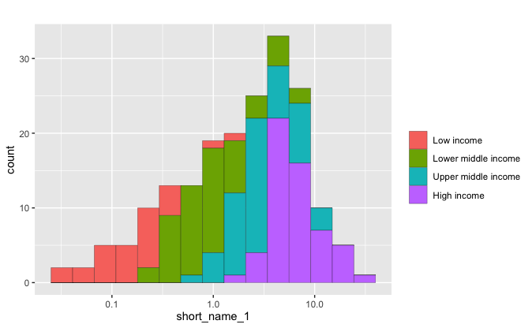

```r
df_yourdata |> filter(year == 2020) |> filter(region != "Aggregates") |>
  drop_na(short_name_1) |> filter(income != "Not classified") |>
  ggplot(aes(short_name_1, fill = factor(income, levels = INCOME))) + geom_histogram(bins = 15, col = "black", linewidth = 0.1) +
  scale_x_log10() +
  labs(title = "", fill = "")
```

**Observations and Questions:**

Edit the title and the years.

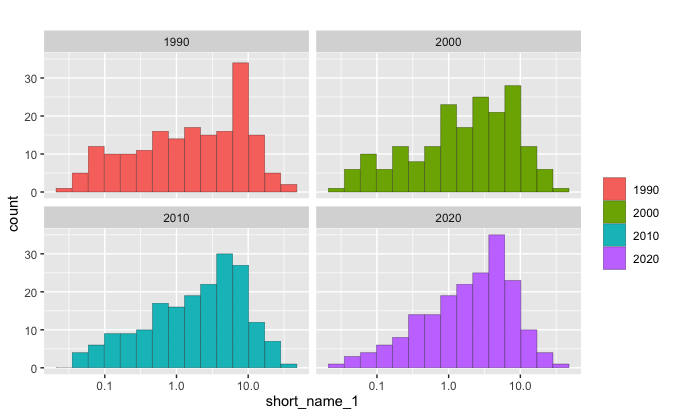

```r
df_yourdata |> filter(year %in% c(1990, 2000, 2010, 2020)) |> filter(region != "Aggregates") |>
  drop_na(short_name_1) |> filter(short_name_1 > 0) |> filter(income != "Not classified") |>
  ggplot(aes(short_name_1, fill = factor(year))) +
  geom_histogram(bins = 15, col = "black", linewidth = 0.1) +
  scale_x_log10() + facet_wrap(~year) +
  labs(title = "", fill = "")
```

**Observations and Questions:**

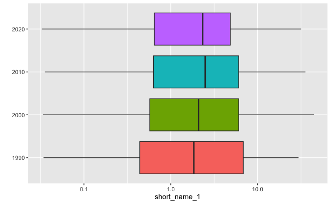

```r
df_yourdata |> filter(year %in% c(1990, 2000, 2010, 2020)) |> filter(region != "Aggregates") |>
  drop_na(short_name_1) |> filter(short_name_1 > 0) |> filter(income != "Not classified") |>
  ggplot(aes(short_name_1, factor(year), fill = factor(year))) +
  geom_boxplot() + scale_x_log10() + labs(y = "") + theme(legend.position = "none")
```

**Observations and Questions:**

Edit the title, and the year if necessary.

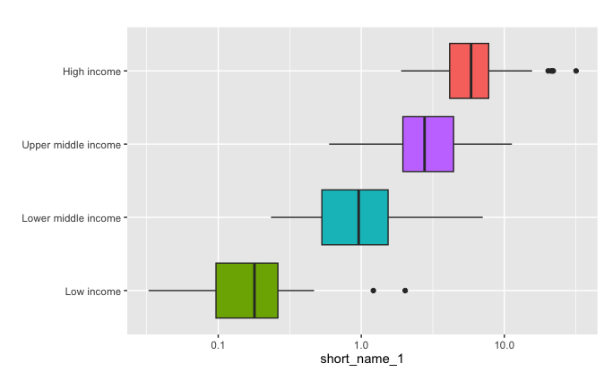

```r
df_yourdata |> filter(year == 2020) |> filter(region != "Aggregates") |>
  drop_na(short_name_1) |> filter(short_name_1 > 0) |> filter(income != "Not classified") |>
  ggplot(aes(short_name_1, factor(income, levels = INCOME), fill = income)) +
  geom_boxplot() + scale_x_log10() +
  labs(title = "", y = "", fill = "") +
  theme(legend.position = "none")
```

**Observations and Questions:**

Edit the title and year if necessary.

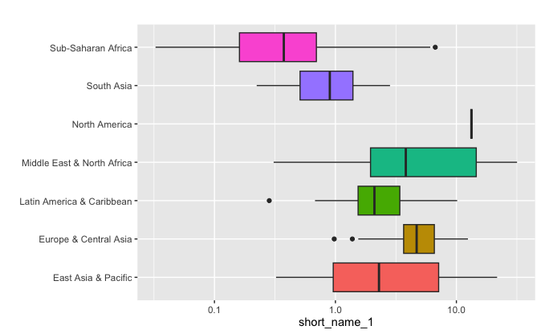

```r
df_yourdata |> filter(year == 2020) |> filter(region != "Aggregates") |>
  drop_na(short_name_1) |> filter(short_name_1 > 0) |>
  ggplot(aes(short_name_1, region, fill = region)) +
  geom_boxplot() + scale_x_log10() +
  labs(title = "", y = "", fill = "") +
  theme(legend.position = "none")
```

**Observations and Questions:**

#### 3.1.3.2 GDP per capita

Edit the title, and year if necessary.

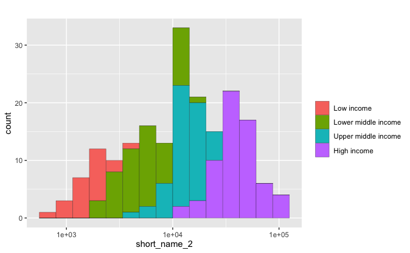

```r
df_yourdata |> filter(year == 2020) |> filter(region != "Aggregates") |>
  drop_na(short_name_2) |> filter(income != "Not classified") |>
  ggplot(aes(short_name_2, fill = factor(income, levels = INCOME))) + geom_histogram(bins = 15, col = "black", linewidth = 0.1) +
  scale_x_log10() +
  labs(title = "", fill = "")
```

Edit the title and the year if necessary.

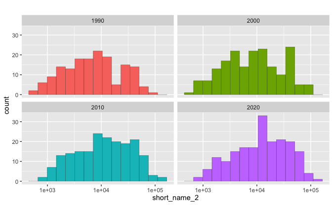

```r
df_yourdata |> filter(year %in% c(1990, 2000, 2010, 2020)) |> filter(region != "Aggregates") |>
  drop_na(short_name_2) |> filter(short_name_2 > 0) |> filter(income != "Not classified") |>
  ggplot(aes(short_name_2, fill = factor(year))) +
  geom_histogram(bins = 15, col = "black", linewidth = 0.1) +
  scale_x_log10() + facet_wrap(~year) +
  labs(title = "", fill = "") +
  theme(legend.position = "none")
```

**Observations and Questions:**

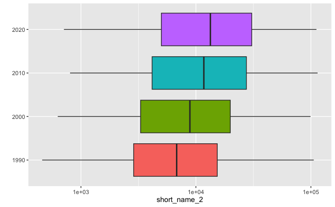

```r
df_yourdata |> filter(year %in% c(1990, 2000, 2010, 2020)) |> filter(region != "Aggregates") |>
  drop_na(short_name_2) |> filter(short_name_2 > 0) |> filter(income != "Not classified") |>
  ggplot(aes(short_name_2, factor(year), fill = factor(year))) +
  geom_boxplot() + scale_x_log10() + labs(y = "") + theme(legend.position = "none")
```

**Observations and Questions:**

Edit the title, and the year if necessary.

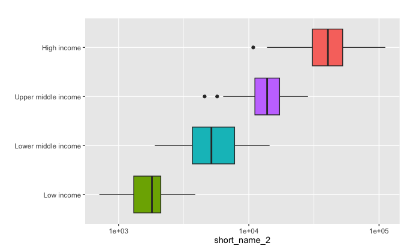

```r
df_yourdata |> filter(year == 2020) |> filter(region != "Aggregates") |>
  drop_na(short_name_2) |> filter(short_name_2 > 0) |> filter(income != "Not classified") |>
  ggplot(aes(short_name_2, factor(income, levels = INCOME), fill = income)) +
  geom_boxplot() + scale_x_log10() +
  labs(title = "", y = "", fill = "") +
  theme(legend.position = "none")
```

**Observations and Questions:**

Edit the title and the year if necessary.

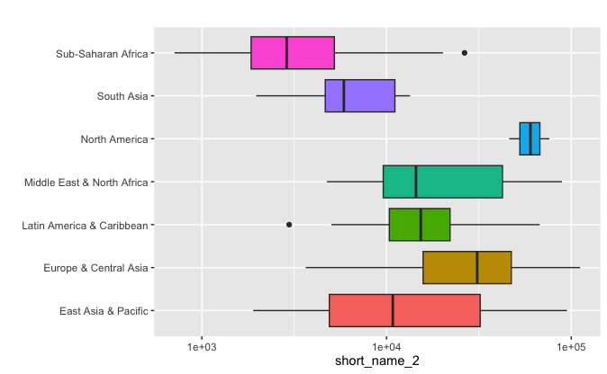

```r
df_yourdata |> filter(year == 2020) |> filter(region != "Aggregates") |>
  drop_na(short_name_2) |> filter(short_name_2 > 0) |>
  ggplot(aes(short_name_2, region, fill = region)) +
  geom_boxplot() + scale_x_log10() +
  labs(title = "", y = "", fill = "") +
  theme(legend.position = "none")
```

### 3.1.4 Scatterplot for Covariation

#### 3.1.4.1 Scatterplot with a regression line

Edit the title, the labels of x- and y- axes.

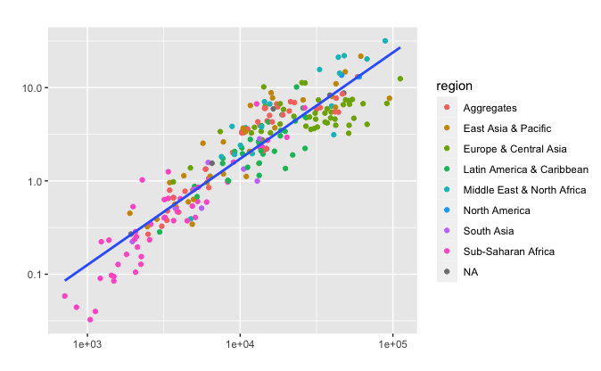

```r
df_yourdata |> filter(year == 2020) |>
  drop_na(short_name_2, short_name_1) |>
  ggplot(aes(short_name_2, short_name_1)) + geom_point(aes(col = region)) +
  geom_smooth(method = "lm", formula = 'y~x', se = FALSE) +
  scale_x_log10() + scale_y_log10() +
  labs(title = "",
       x = "",
       y = "")
```

**Observations and Questions:**

#### 3.1.4.2 Summary of a linear model

Edit year if necessary.

```r
df_yourdata |> filter(year == 2020) |> drop_na(short_name_2, short_name_1) |>
  lm(log10(short_name_1)~log10(short_name_2), data = _) |> summary()
```

```
Call:
lm(formula = log10(short_name_1) ~ log10(short_name_2), data = drop_na(filter(df_yourdata,
    year == 2020), short_name_2, short_name_1))

Residuals:
     Min       1Q   Median       3Q      Max
-0.60778 -0.15660 -0.00651  0.16129  0.59437

Coefficients:
                    Estimate Std. Error t value Pr(>|t|)
(Intercept)         -4.31545    0.13386  -32.24   <2e-16 ***
log10(short_name_2)  1.13831    0.03288   34.62   <2e-16 ***
---
Signif. codes:  0 ‘***’ 0.001 ‘**’ 0.01 ‘*’ 0.05 ‘.’ 0.1 ‘ ’ 1

Residual standard error: 0.2362 on 228 degrees of freedom
Multiple R-squared:  0.8402,    Adjusted R-squared:  0.8395
F-statistic:  1199 on 1 and 228 DF,  p-value: < 2.2e-16
```

**Observations and Questions:**